# Complete Lipid saturation

Dan Ackerman

December 14, 2015

Attempting to create dataframe containing full results of August 2015 analysis of SCD1i in vitro veh and dox cells. This dataframe should contain all saturation information about TGs and all different PLs.

First step, creating combined dataframe. (as previously)

```r
require(dplyr); require(ggplot2)
setwd("C:/R/Aug2015")
dat1<-read.table("Input_data_InVitro_0.5%_DMSO_DOXvsVehicle.csv", header=TRUE, sep=",")
dat2<-read.table("Input_data_InVitro_0.5%_SCDi_DOXvsVehicle.csv", header=TRUE, sep=",")

rep1<-read.table("Input_data_InVitro_5%_DMSO_DOXvsVehicle.csv", header=TRUE, sep=",")
rep2<-read.table("Input_data_InVitro_5%_SCDi_DOXvsVehicle.csv", header=TRUE, sep=",")

dat3<-merge(dat1, dat2, by="Label")
rep3<-merge(rep1, rep2, by="Label")
colnames(dat3)<-c(colnames(dat3)[1], paste0("S-", colnames(dat3[2:21])))
colnames(rep3)<-c(colnames(rep3)[1], paste0("R-", colnames(rep3[2:20])))
comb1<-merge(dat3, rep3, by="Label")
library(stringr)
n<- length(grep("_", names(comb1)))
```

Next, trying to extract different patterns for different lipids.

Next, adding total amount of lipid with differnt levels of saturation

```r
require(data.table); require(tidyr)
```

```r
tot.unsat2<- function(df, cl){
    if (!"ch1DBs" %in% names(df)){
    stop("df must contain ch1DBs column")
  }
  exclude<- c('Label',"ch1", "ch1DBs", "Species")
  if(cl=="CL1"){
    df$unsat<- as.numeric(as.character(df$ch1DBs))
  }
  if(cl=="CL2"){
    df$unsat<- as.numeric(as.character(df$ch1DBs))+as.numeric(as.character(df$ch2DBs))
    exclude<- c(exclude, c("ch2", "ch2DBs", "Add1", "Add2"))
  }
    if(cl=="CL3"){
    df$unsat<- as.numeric(as.character(df$ch1DBs))+as.numeric(as.character(df$ch2DBs))+ as.numeric(df$ch3DBs)
    exclude<- c(exclude, c("ch2", "ch2DBs", "ch3", "ch3DBs"))
    }
   df2<-setDT(df)[,lapply(.SD, sum), by=unsat, .SDcols=-exclude]
   df2
}

satlist2<- Map(tot.unsat2, satlist1, chain_no)
#tg3<- satlist2[["TG"]]
```

Next, I would like to divide each value by the total amount of that particular lipid species in that sample.

```r
# scaling each sample to look at distribution of each lipid as percentage shift
# does not take into account changes in abundance of different lipid species across groups

scal<- function(DAT){
  x<-DAT$unsat
  nms<- colnames(DAT)
  df2<-sweep(DAT,2,colSums(DAT), "/")
  df2$unsat<- x
  colnames(df2)<- nms
  df2[order(df2$unsat),]
}
satlist3<- lapply(satlist2, scal)
#p1<- satlist3[["TG"]]

scal2<- function(df, exclude = c()){
  ##df must contain column named "unsat"

  exclude2<- c("unsat", exclude)
  excluded<- select(df, one_of(exclude2))
  included<- names(df)[!(names(df)%in% exclude2)]
  DAT<- select(df, one_of(included))
  df2<-sweep(DAT,2,colSums(DAT), "/")
  df3<- cbind(excluded, df2)
  df3[order(df3$unsat),]

  }
```

Next, center to look at effect of a treatment on distribution as shift

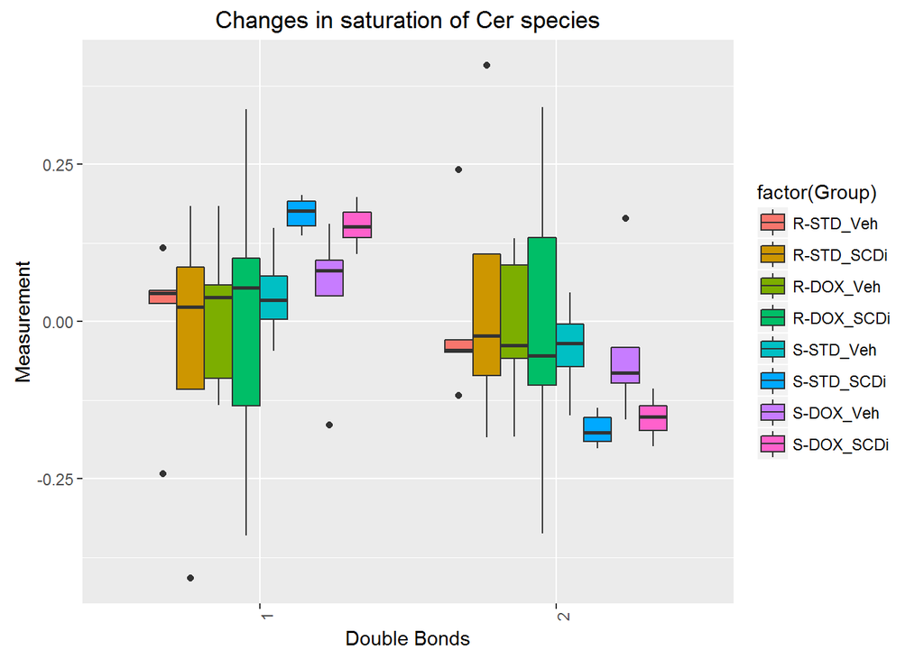

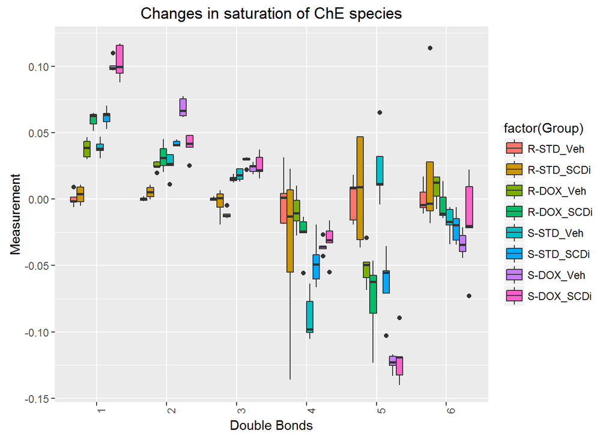

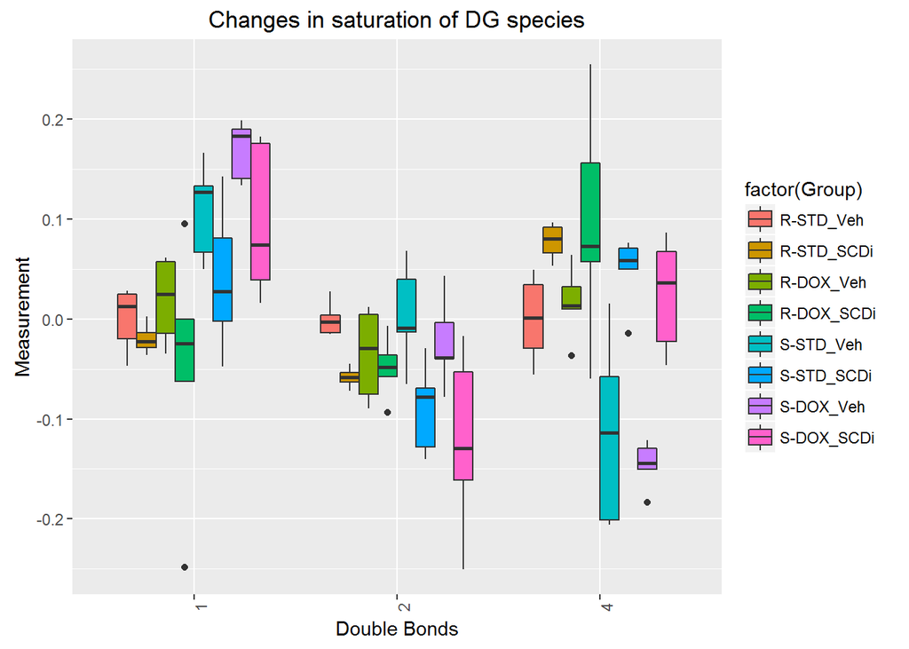

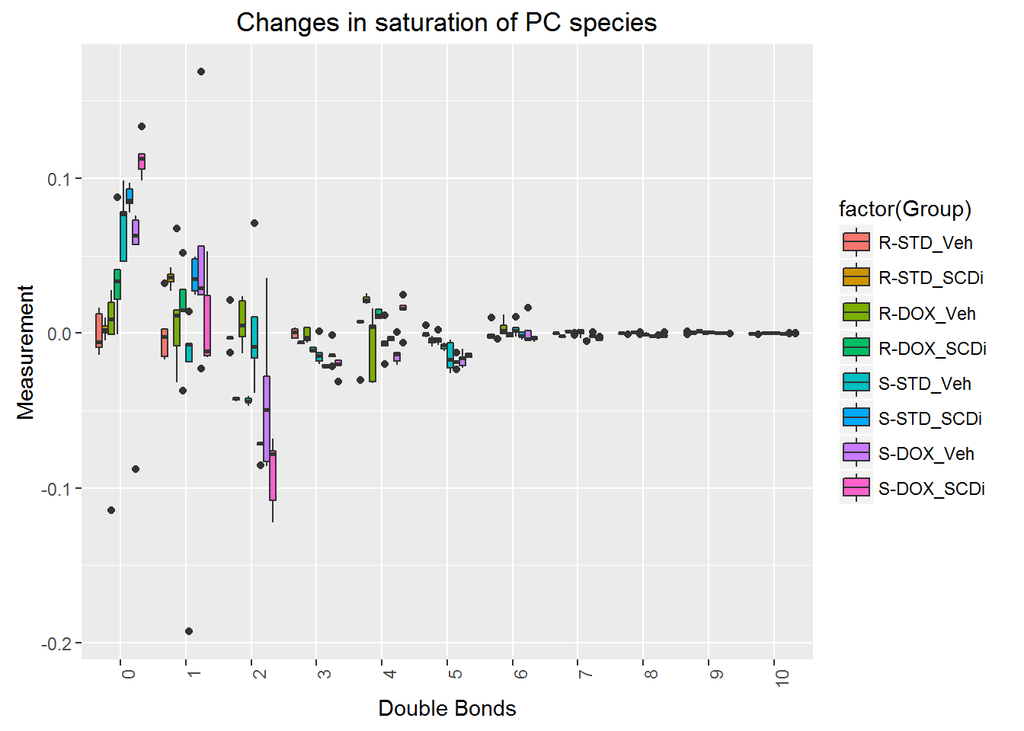

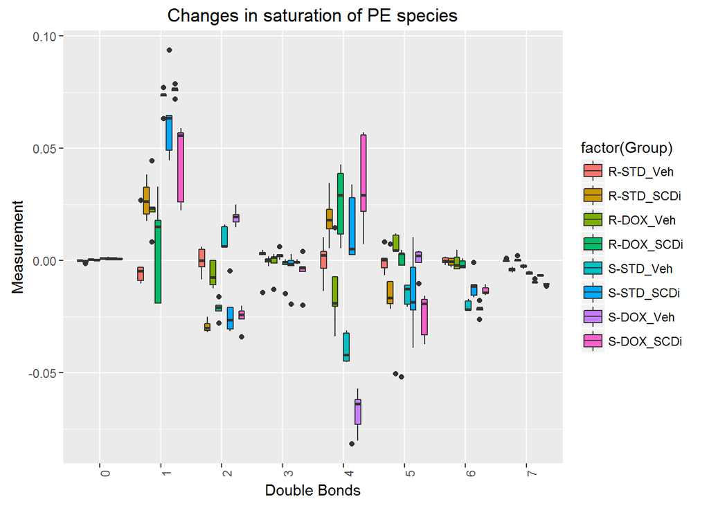

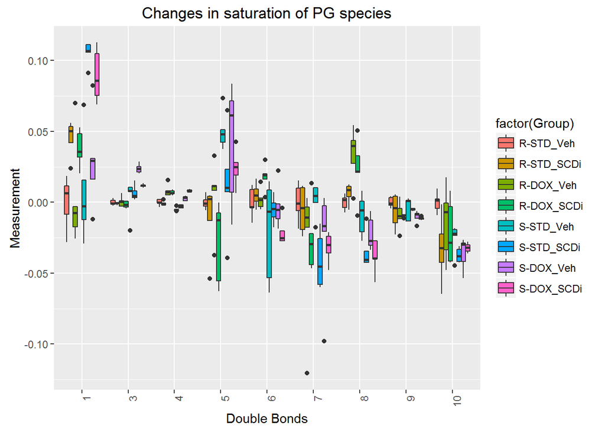

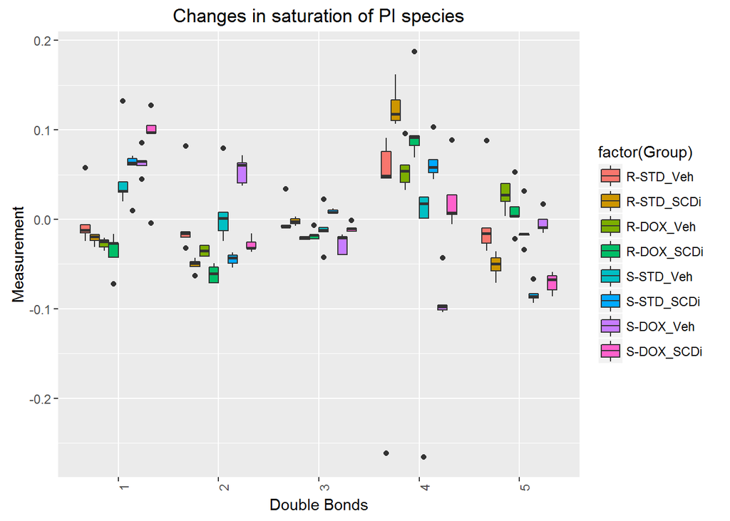

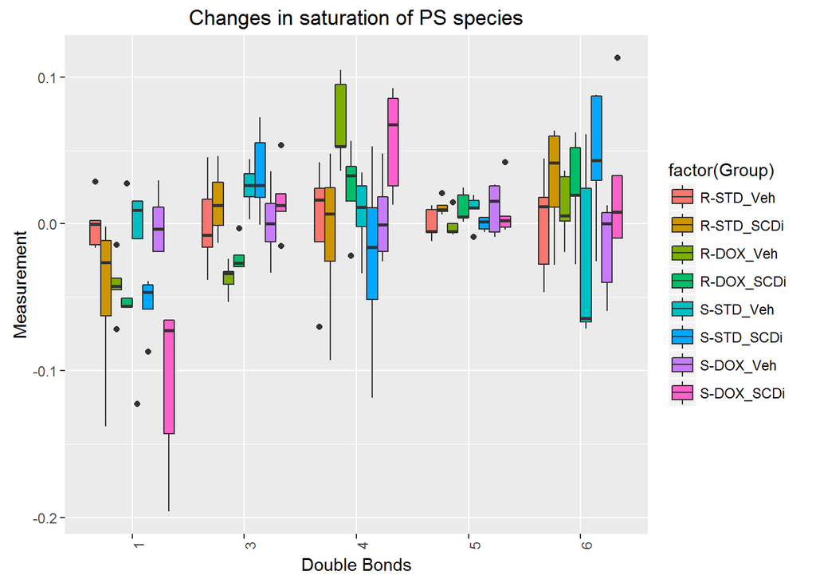

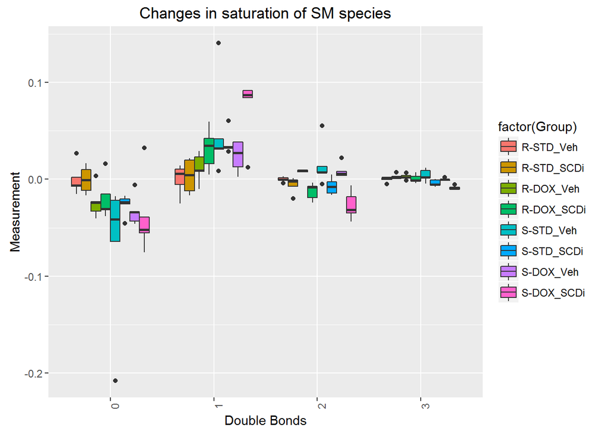

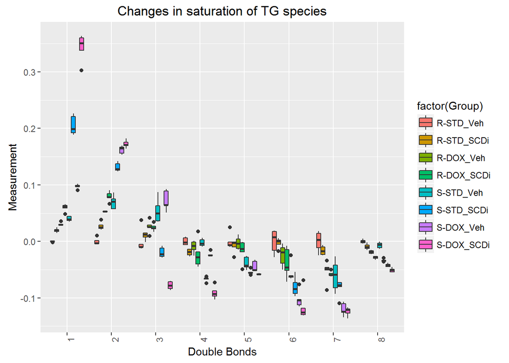

```r
centr<- function(df, controls){
  # takes a dataframe and a vector of sample names
  # calculates mean of each saturatio value across control samples
  # subtracts mean from all values
  df_ctrl<- df[,names(df) %in% controls]
  df2<- sweep(df, 1, rowMeans(df_ctrl), "-")
  df2$unsat<- df$unsat
  df2
}
# center around R-STD_Veh group
conts1<- names(satlist3[["PC"]])[22:26]
R_centlist<- lapply(satlist3, centr, conts1)

#tg1<-R_centlist[["TG"]]

# p2<-centr(satlist3[["PC"]], conts1)
# identical(R_centlist[["PC"]], p2)


require(tidyr); require(ggplot2)

diff.plot<- function(df, exclude=c(), order=c()){
  ## function that takes centered dataframe created by centr()
  ## converts into long format
  ## graphs it in ggplot2
  ## contains argument that takes list of column names to exclude
  ## contains argument that allows user to decide which order to graph in (levels for ggplot2)
  ## naming of samples has to be as follows:
  ### column names match group names with "_1", "_2", etc to identify individual samples

    long_df<- gather(df, Sample, Measurement, 2:length(colnames(df)))
    long_df$Group<-unlist(strsplit(as.character(long_df$Sample), '[1-5]$'))
    long_df$Group<- gsub("_$", "", long_df$Group)
    long_df2<- long_df[!(long_df$Sample %in% exclude),]
    try(long_df2$Group<- factor(long_df2$Group, levels = order))
    ##plotting
    p<-ggplot(long_df2,
      aes(x=factor(unsat), y=Measurement, fill= factor(Group)))
    p<- p +    geom_boxplot()
    p<- p + theme(axis.text.x = element_text(angle = 90, hjust = 1)) +  labs(x="Double Bonds")
    p
}

plot_list1<- lapply(R_centlist, diff.plot)
order1<- c("R-STD_Veh", "R-STD_SCDi", "R-DOX_Veh", "R-DOX_SCDi",
           "S-STD_Veh", "S-STD_SCDi", "S-DOX_Veh", "S-DOX_SCDi")
exclude1<- c()
plot_list1<- lapply(R_centlist, diff.plot, exclude1, order1)
# plot_list1[["TG"]]


for (i in names(plot_list1)){
  plot_list2<- vector("list", length(names(plot_list1)))
  plot_list2[[i]]<-plot_list1[[i]]+ ggtitle(paste("Changes in saturation of", i, "species"))
  }

plot_list2<- vector("list", length(names(plot_list1)))
names(plot_list2)<- names(plot_list1)
for (i in names(plot_list1)){
  plot_list2[[i]]<-plot_list1[[i]]+ ggtitle(paste("Changes in saturation of", i, "species"))
  }

for (i in names(plot_list2)){
  print(plot_list2[[i]])
  }
```

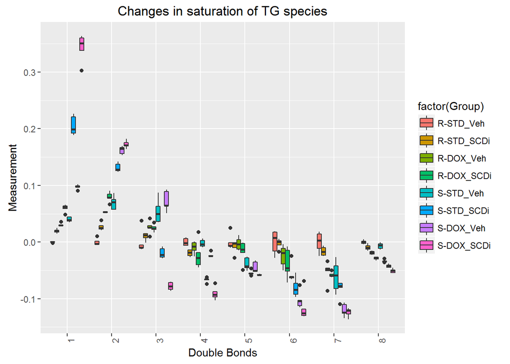

```r
plot_list2[["TG"]]
```

Next I want to make publishable figures that illustrate the changes in saturation from two samples

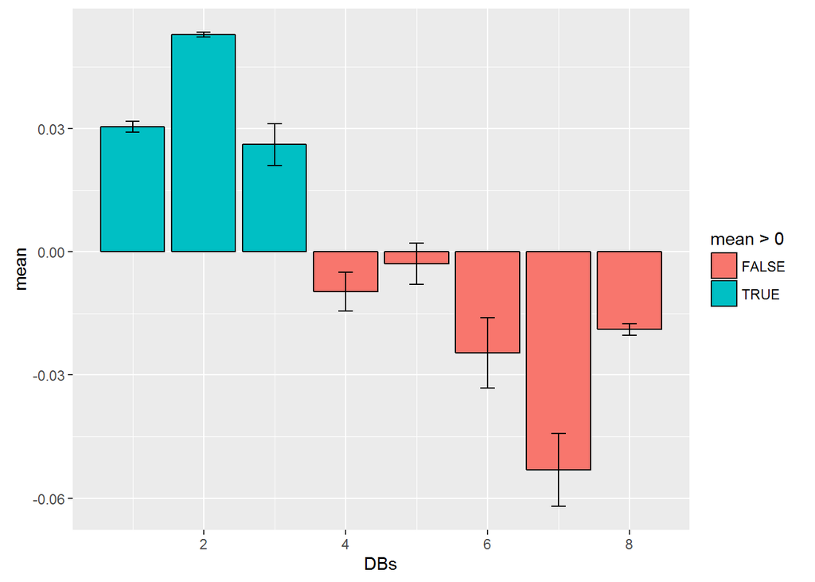

```r
se <- function(x) sqrt(var(x)/length(x))

mneffect<- function(df, control, treatment){
  #function that graphs changes in saturation profile between two groups
  #takes a dataframe and two strings of column names
  #output is gg barplot

  #### include some stop options if control and treatment columns are not present in names(df)

  df_control<- df[, names(df) %in% control]
  df_treat<- df[, names(df) %in% treatment]
  df_diff<- sweep(df_treat, 1, rowMeans(df_control), "-")

  ##Create df with all the data required for ggplot
  df_diff2<- data.frame(DBs=df[,1])
  df_diff2$mean<- apply(df_diff,1,mean)
  df_diff2$sd<- apply(df_diff,1,se)
  df_diff2$ctrlmn<- rowMeans(df_control)



    z<- ggplot(df_diff2, aes(x=DBs, y=mean, fill=mean>0))+
       geom_bar(stat="identity", position="identity", color="black", size=0.5)+
      geom_errorbar(aes(ymin=mean-sd, ymax=mean+sd),
                  width=.2,                    # Width of the error bars
                  position=position_dodge(.9))+
      scale_x_continuous(breaks=seq(0,9,1))+
      scale_y_continuous(breaks=seq(-0.1,0.3,0.05))+
      scale_fill_manual(values=c("#CCEEFF", "#FFDDDD"), guide=FALSE) +
      geom_hline(aes(yintercept=0))+labs(y="relative change")+
      coord_cartesian(xlim = c(0.5, 8.5), ylim=c(-.2, 0.45))+
      theme(axis.title.x=element_text(size = 25), axis.text.x=element_text(size=30),
        axis.title.y=element_text(size = 25), axis.text.y=element_text(size=30))+
      theme_bw()+

    geom_point(aes(size=ctrlmn, x= DBs, y=0.35),
               shape = 21, color= "black", fill= "cornsilk")+
        scale_size_area(max_size=6.5, guide=FALSE)+
        annotate("text", x=4.5, y=0.43, label= "TG species", size=5)+
        annotate("text", x=4.5, y=0.39, label= "Abundance", size=3.5)
  z

}

mneffect2<- function(df, control, treatment){
  #function that graphs changes in saturation profile between two groups
  #takes a dataframe and two strings of column names
  #output is gg barplot

  #### include some stop options if control and treatment columns are not present in names(df)

  df_control<- df[, names(df) %in% control]
  df_treat<- df[, names(df) %in% treatment]
  df_diff<- sweep(df_treat, 1, rowMeans(df_control), "-")

  ##Create df with all the data required for ggplot
  df_diff2<- data.frame(DBs=df[,1])
  df_diff2$mean<- apply(df_diff,1,mean)
  df_diff2$sd<- apply(df_diff,1,se)
  df_diff2$ctrlmn<- rowMeans(df_control)



    z<- ggplot(df_diff2, aes(x=DBs, y=mean, fill=mean>0))+
       geom_bar(stat="identity", position="identity", color="black", size=0.5)+
      geom_errorbar(aes(ymin=mean-sd, ymax=mean+sd),
                  width=.2,                    # Width of the error bars
                  position=position_dodge(.9))
        z

}



TG_effects<- function(lst, grp1, grp2){
  ## takes two text strings, identifies columns in df with those names
  ## takes list, extracts "TG" element as dataframe
  ## performs mneffect() function on those columns

  df<-lst[["TG"]]
  cols1<- grep(grp1, names(df), value=TRUE)
  cols2<- grep(grp2, names(df), value=TRUE)
  p<- mneffect2(df, cols1, cols2)
  p
}

# rSTD_Veh<- grep("R-STD_Veh", names(satlist3[["TG"]]), value=TRUE)
# sSTD_Veh<- grep("S-STD_Veh", names(satlist3[["TG"]]), value=TRUE)
#
# mneffect(satlist3[["TG"]], rSTD_Veh, sSTD_Veh)

serum_effect<-TG_effects(satlist3, "R-STD_Veh", "S-STD_Veh")
TG_effects(satlist3, "R-STD_Veh", "R-DOX_Veh")
```

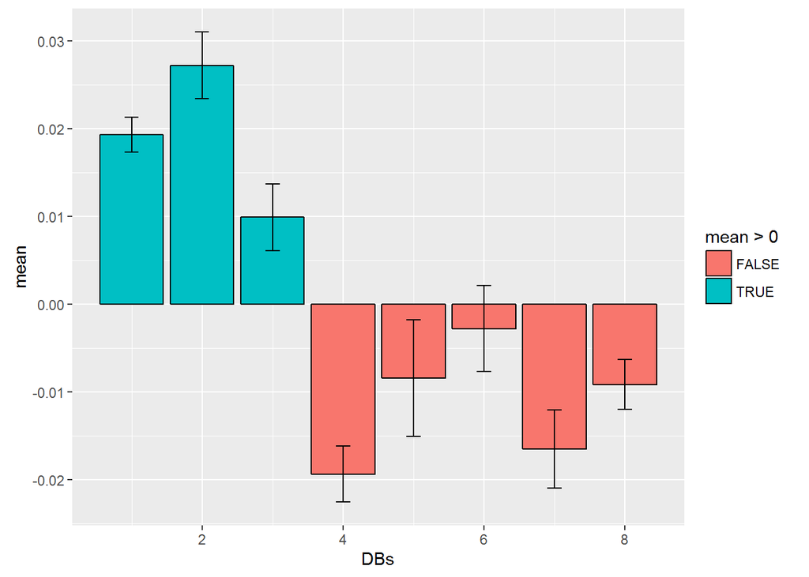

```r
TG_effects(satlist3, "R-STD_Veh", "R-STD_SCDi")
```

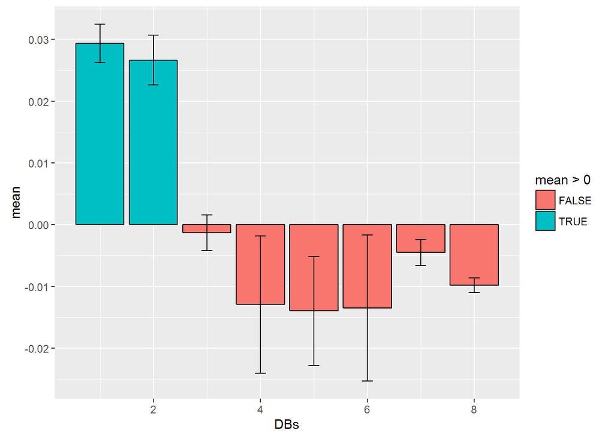

```r
TG_effects(satlist3, "R-DOX_Veh", "R-DOX_SCDi")
```

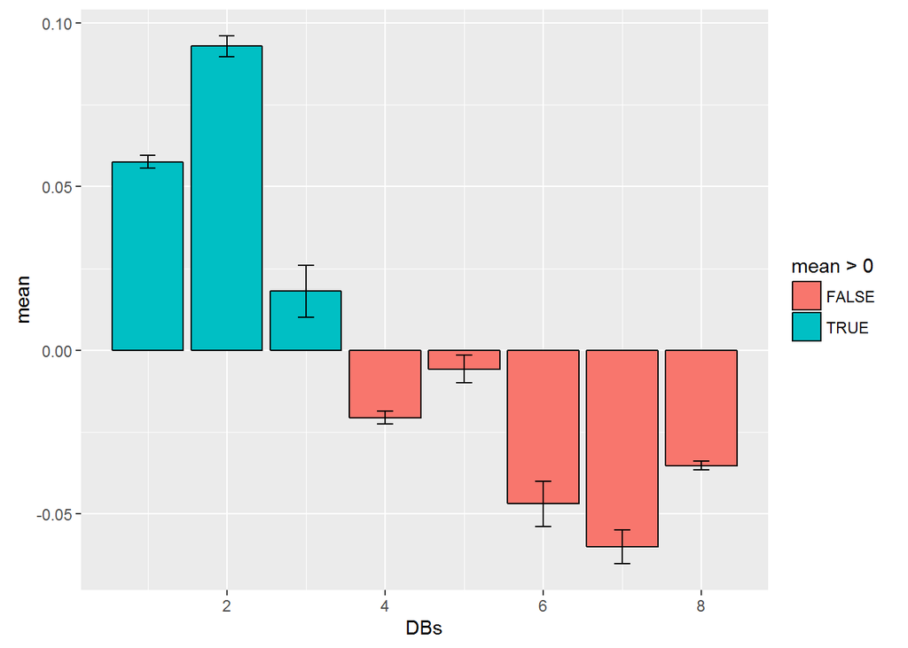

```r
TG_effects(satlist3, "S-STD_Veh", "S-DOX_Veh")
```

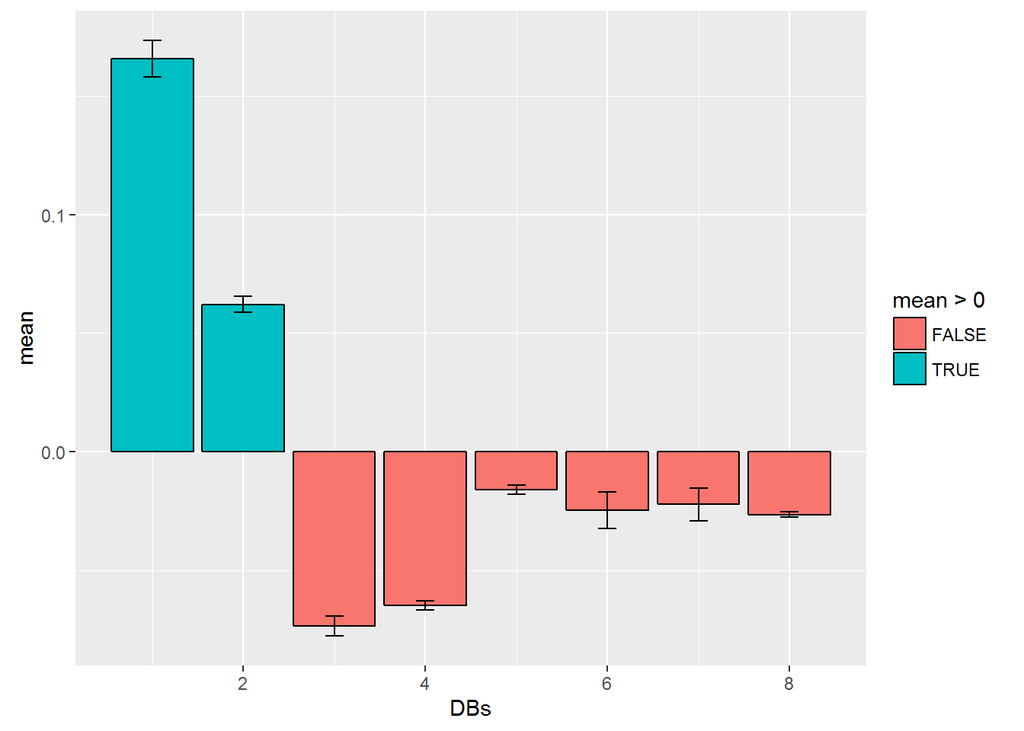

```r
TG_effects(satlist3, "S-STD_Veh", "S-STD_SCDi")
```

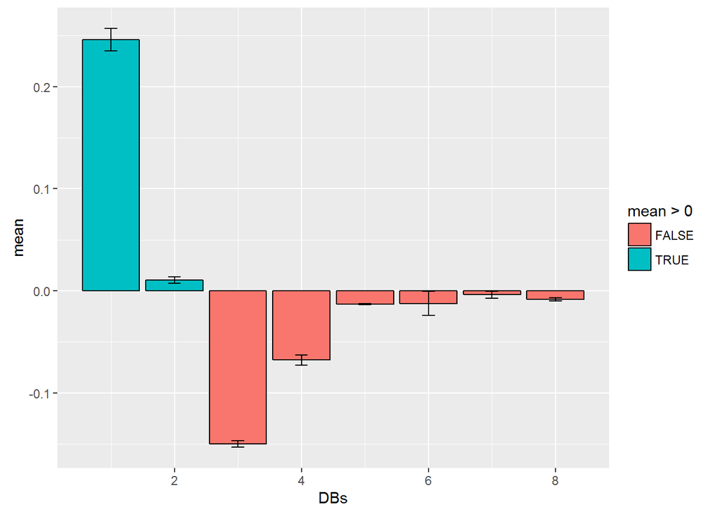

```r
TG_effects(satlist3, "S-DOX_Veh", "S-DOX_SCDi")
```

```r
names(satlist3[["TG"]])
```

```
##  [1] "unsat"        "S-STD_Veh_1"  "S-STD_Veh_2"  "S-STD_Veh_3"
##  [5] "S-STD_Veh_4"  "S-STD_Veh_5"  "S-DOX_Veh_1"  "S-DOX_Veh_2"
##  [9] "S-DOX_Veh_3"  "S-DOX_Veh_4"  "S-DOX_Veh_5"  "S-STD_SCDi_1"
## [13] "S-STD_SCDi_2" "S-STD_SCDi_3" "S-STD_SCDi_4" "S-STD_SCDi_5"
## [17] "S-DOX_SCDi_1" "S-DOX_SCDi_2" "S-DOX_SCDi_3" "S-DOX_SCDi_4"
## [21] "S-DOX_SCDi_5" "R-STD_Veh_1"  "R-STD_Veh_2"  "R-STD_Veh_3"
## [25] "R-STD_Veh_4"  "R-STD_Veh_5"  "R-DOX_Veh_1"  "R-DOX_Veh_2"
## [29] "R-DOX_Veh_3"  "R-DOX_Veh_4"  "R-DOX_Veh_5"  "R-STD_SCDi_1"
## [33] "R-STD_SCDi_2" "R-STD_SCDi_3" "R-STD_SCDi_5" "R-DOX_SCDi_1"
## [37] "R-DOX_SCDi_2" "R-DOX_SCDi_3" "R-DOX_SCDi_4" "R-DOX_SCDi_5"
```

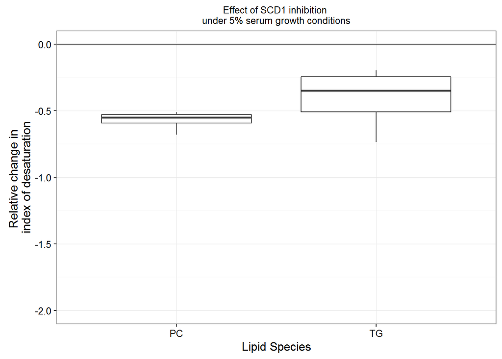

```r
serum_effect2<-TG_effects(satlist3, "R-STD_Veh", "S-STD_Veh")
SCD_effect_R<- TG_effects(satlist3, "R-STD_Veh", "R-STD_SCDi")

serum_effect3<- serum_effect2 +  scale_x_continuous(breaks=seq(0,9,1))+
      scale_y_continuous(breaks=seq(-0.1,0.075,0.025))+
      scale_fill_manual(values=c("#CCEEFF", "#FFDDDD"), guide=FALSE) +
      geom_hline(aes(yintercept=0))+labs(y="Relative Change", x= "Double Bonds")+
      coord_cartesian(xlim = c(0.5, 8.5), ylim=c(-0.075, 0.12))+
      theme(axis.title.x=element_text(size = 25), axis.text.x=element_text(size=30),
        axis.title.y=element_text(size = 25), axis.text.y=element_text(size=30))+
      theme_bw() + geom_point(aes(size=ctrlmn, x= DBs, y=0.105), shape = 21, color= "black", fill= "cornsilk")+
        scale_size_area(max_size=6.5, guide=FALSE)+
        annotate("text", x=4.5, y=0.085, label= "Change in TG saturation", size=3)+
        annotate("text", x=4.5, y=0.12, label= "Abundance", size=3)

############ Figure generation######################################################
#ggsave("./20160126/TG_serum_effect.pdf", plot = serum_effect3, width=3, height=4, useDingbats=FALSE)
## used this to generate figure. Had to change plot thickness to 2 in illustrator
##very important to use useDingbats=FALSE here for geom_point to be visible in Illustrator
####################################################################################

rdox_effect<- TG_effects(satlist3, "R-STD_Veh", "R-DOX_Veh")
sdox_effect<- TG_effects(satlist3, "S-STD_Veh", "S-DOX_Veh")
rdox_effect2<- rdox_effect+  scale_x_continuous(breaks=seq(0,9,1))+
      scale_y_continuous(breaks=seq(-0.1,0.1,0.025))+
      scale_fill_manual(values=c("#CCEEFF", "#FFDDDD"), guide=FALSE) +
      geom_hline(aes(yintercept=0))+labs(y="Relative Change", x= "Double Bonds")+
      coord_cartesian(xlim = c(0.5, 8.5), ylim=c(-0.07, 0.1))+
      theme(axis.title.x=element_text(size = 25), axis.text.x=element_text(size=30),
        axis.title.y=element_text(size = 25), axis.text.y=element_text(size=30))+ theme_bw() +
      ggtitle("Change in TG saturation after \nDGAT loss under 5% serum")
sdox_effect2<-sdox_effect+  scale_x_continuous(breaks=seq(0,9,1))+
      scale_y_continuous(breaks=seq(-0.1,0.1,0.025))+
      scale_fill_manual(values=c("#CCEEFF", "#FFDDDD"), guide=FALSE) +
      geom_hline(aes(yintercept=0))+labs(y="Relative Change", x= "Double Bonds")+
      coord_cartesian(xlim = c(0.5, 8.5), ylim=c(-0.07, 0.1))+
      theme(axis.title.x=element_text(size = 25), axis.text.x=element_text(size=30),
        axis.title.y=element_text(size = 25), axis.text.y=element_text(size=30))+
      theme_bw() + ggtitle("Change in TG saturation after \nDGAT loss under 0.5% serum")
############ Figure generation######################################################
#ggsave("./20160127/rdoxeffect.pdf", plot = rdox_effect2, width=2.5, height=4, useDingbats=FALSE)
#ggsave("./20160127/sdoxeffect.pdf", plot = sdox_effect2, width=2.5, height=4, useDingbats=FALSE)
## used this to generate figure. Had to change plot thickness to 2 in illustrator
##very important to use useDingbats=FALSE here for geom_point to be visible in Illustrator
####################################################################################


FAsplit<- function(df){
  ## function to take dataframe of lipids and split into individual FA chains
  ## df needs to contain columns with chain length and number of double bonds for each FA
  ## this was done above using stringr breakup of lipid name into constituents
  ## takes each TG and introduces that entry three times, once for each FA chain,
  ## preserving only chain length/saturation for one of the chains in each entry.
  ## assumes the following naming for columns:
          ### All sample column names include "_"
          ### chain length columns named "ch1", "ch2", "ch3" ("ch2" and "ch3" might be absent)
          ### DB number columns "ch1DBs", "ch2DBs", "ch3DBs" (last two might be absent)

  ch1<- c(grep("ch1$", names(df)), grep("ch1DBs", names(df)))
  ch2<- c(grep("ch2$", names(df)), grep("ch2DBs", names(df)))
  ch3<- c(grep("ch3$", names(df)), grep("ch3DBs", names(df)))

  if (!("ch1" %in% names(df) & "ch1DBs" %in% names(df))){
    stop("chain length and saturation not provided in correct format")
  }
  cols1<- c(ch1, grep("_", names(df)))
  df2<- df[,cols1]
  names(df2)<- c("length", "unsat", names(df)[grep("_", names(df))])

  if ("ch2" %in% names(df) & "ch2DBs" %in% names(df)){
    cols2<- c(ch2, grep("_", names(df)))
    df_ch2<- df[,cols2]
    names(df_ch2)<- c("length", "unsat", names(df)[grep("_", names(df))])
    df2<- rbind(df2, df_ch2)
  }

  if ("ch3" %in% names(df) & "ch3DBs" %in% names(df)){
    cols3<- c(ch3, grep("_", names(df)))
    df_ch3<- df[,cols3]
    names(df_ch3)<- c("length", "unsat", names(df)[grep("_", names(df))])
    df2<- rbind(df2, df_ch3)
  }
  df2
}

byFAlist1<- lapply(satlist1 , FAsplit)
byFAlist2<- lapply(byFAlist1, scal2, exclude= c("length"))

FAs<- byFAlist1[["PC"]]

desat.index<- function(df, exclude=c()){
  ## function takes df with following columns
  ### Samples with lipid quantity measurements
  ### each row is one lipid measurement
  ### column named "unsat" containing number of double bonds in that lipid
  ## calculates desaturation index for each sample
  ## allows for exclusion of columns from calculation

  exclude2<- c("unsat", exclude)  #vector of columns to exclude from calculation
  excluded<- select(df, one_of(exclude2))   # df of excluded columns
  include<- names(df)[!(names(df)%in% exclude2)]  # vector of columns to include
  DAT<- select(df, one_of(include))  #df of columns of interest
  excluded$unsat<- as.numeric(excluded$unsat)
  DAT2<- sweep(DAT, 1, excluded$unsat, "*")
  Vec1<- colMeans(DAT2)
  names(Vec1)<- names(DAT2)
  Vec1
}


DesatIndex1<- vapply(byFAlist2, desat.index, exclude= c("length"), FUN.VALUE = numeric(n))
DesatIndex2<- data.frame(DesatIndex1)
lipids<- names(DesatIndex2)
DesatIndex2$Sample<- row.names(DesatIndex2)


sSTD_Veh<- grep("S-STD_Veh" , DesatIndex2$Sample, value = TRUE)
sSTD_SCDi<- grep("S-STD_SCDi" , DesatIndex2$Sample, value = TRUE)

sDOX_Veh<- grep("S-DOX_Veh" , DesatIndex2$Sample, value = TRUE)
sDOX_SCDi<- grep("S-DOX_SCDi" , DesatIndex2$Sample, value = TRUE)

rSTD_Veh<- grep("R-STD_Veh" , DesatIndex2$Sample, value = TRUE)
rSTD_SCDi<- grep("R-STD_SCDi" , DesatIndex2$Sample, value = TRUE)

rDOX_Veh<- grep("R-DOX_Veh" , DesatIndex2$Sample, value = TRUE)
rDOX_SCDi<- grep("R-DOX_SCDi" , DesatIndex2$Sample, value = TRUE)
lipids2<- lipids[!(lipids %in% c("Cer", "ChE", "DG", "PG", "PI", "PS", "PE", "SM"))]

desat.effect<- function(df, control, treatment, lipids){
  df_control<- filter(df, Sample %in% control) %>% select(one_of(lipids))
  df_treat<- filter(DesatIndex2, Sample %in% treatment) %>% select(one_of(lipids))
  df_diff<- sweep(df_treat, 2, colMeans(df_control), "-")
  long<- gather(df_diff)
  long$value<- long$value*1000
  long<- filter(long, key %in% lipids)
  p<- ggplot(long, aes(x=key, y=value))+ geom_boxplot()
  p
}
# desat.effect(DesatIndex2, rSTD_Veh, rSTD_SCDi) + ggtitle("Effect of SCDi under R condition")
# desat.effect(DesatIndex2, sSTD_Veh, sSTD_SCDi) + ggtitle("SCDi effect under S condition")
# desat.effect(DesatIndex2, sDOX_Veh, sDOX_SCDi) + ggtitle("SCDi effect under S condition after DGAT knockdown")
# desat.effect(DesatIndex2, rDOX_Veh, rDOX_SCDi) + ggtitle("SCDi effect under R condition after DGAT knockdown")
#
# desat.effect(DesatIndex2, rSTD_Veh, rDOX_Veh) + ggtitle("Effect of DGAT knockdown under R condition")
# desat.effect(DesatIndex2, sSTD_Veh, sDOX_Veh) + ggtitle("Effect of DGAT knockdown under S condition")


##removing some lipid species
# desat.effect(DesatIndex2, rSTD_Veh, rSTD_SCDi, lipids = lipids2) + ggtitle("Effect of SCDi under R condition")+ coord_cartesian(ylim=c(-2, 0.01))
#
# desat.effect(DesatIndex2, sSTD_Veh, sSTD_SCDi, lipids = lipids2) + ggtitle("SCDi effect under S condition")+ coord_cartesian(ylim=c(-2, 0.01))



# desat.effect(DesatIndex2, sDOX_Veh, sDOX_SCDi, lipids = lipids2) + ggtitle("SCDi effect under S condition after DGAT knockdown")+ coord_cartesian(ylim=c(-0.002, 0.00125))
# desat.effect(DesatIndex2, rDOX_Veh, rDOX_SCDi, lipids = lipids2) + ggtitle("SCDi effect under R condition after DGAT knockdown")+ coord_cartesian(ylim=c(-0.002, 0.00125))
#
# desat.effect(DesatIndex2, rSTD_Veh, rDOX_Veh, lipids = lipids2) + ggtitle("Effect of DGAT knockdown under R condition")+ coord_cartesian(ylim=c(-0.002, 0.00125))
# desat.effect(DesatIndex2, sSTD_Veh, sDOX_Veh, lipids = lipids2) + ggtitle("Effect of DGAT knockdown under S condition")+ coord_cartesian(ylim=c(-0.002, 0.00125))


rSCDi<-  desat.effect(DesatIndex2, rSTD_Veh, rSTD_SCDi, lipids = lipids2) + ggtitle("Effect of SCD1 inhibition \nunder 5% serum growth conditions")+  theme_bw() +labs(y="Relative change in \nindex of desaturation", x= "Lipid Species")+ coord_cartesian(ylim=c(-2, 0))+ geom_hline(aes(yintercept=0))+ theme(plot.title=element_text(size=rel(0.8)))
#+theme(axis.title.x=element_text(size = 25), axis.text.x=element_text(size=20),
 #       axis.title.y=element_text(size = 25), axis.text.y=element_text(size=20))
rSCDi
```

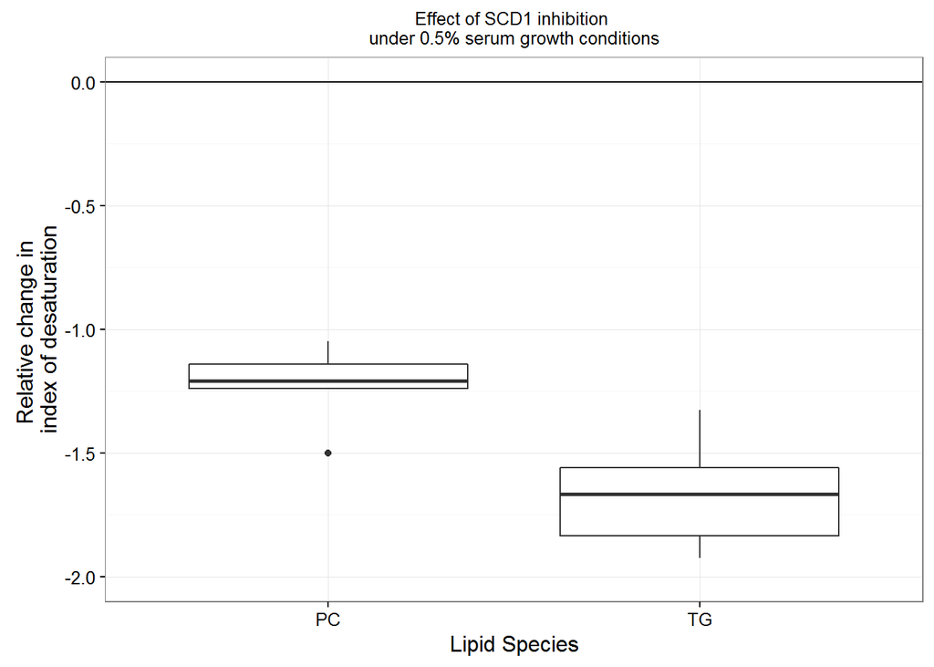

```r
sSCDi<-  desat.effect(DesatIndex2, sSTD_Veh, sSTD_SCDi, lipids = lipids2) + ggtitle("Effect of SCD1 inhibition \nunder 0.5% serum growth conditions")+  theme_bw() +labs(y="Relative change in \nindex of desaturation", x= "Lipid Species")+ coord_cartesian(ylim=c(-2, 0))+ geom_hline(aes(yintercept=0))+ theme(plot.title=element_text(size=rel(0.8)))
sSCDi
```

```r
#################################################################################
##making figure here
# ggsave("./20160127/rSCDi.pdf", plot = rSCDi, width=3, height=4, useDingbats=FALSE)
# ggsave("./20160127/sSCDi.pdf", plot = sSCDi, width=3, height=4, useDingbats=FALSE)
#################################################################################

# ggsave("./20160127/rSCDi2.pdf", plot = rSCDi, width=2, height=4, useDingbats=FALSE)
# ggsave("./20160127/sSCDi2.pdf", plot = sSCDi, width=2, height=4, useDingbats=FALSE)
```

In order to create a figure showing changes in the abundance of all lipid types, create a function that summarizes a list containing all raw data into a dataframe containing the mean abundance for each lipid type (rows) for each sample (columns).

Once this dataset is available, a function that creates a heatmap of changes in abundance for each pairwise comparison is required.

Given that identifying and removing outliers was critical for the accurate assessment of TG abundance, an improvement to this function would be one that automates outlier identification and censoring for this dataset. THis function could then be applied throughout the analysis.

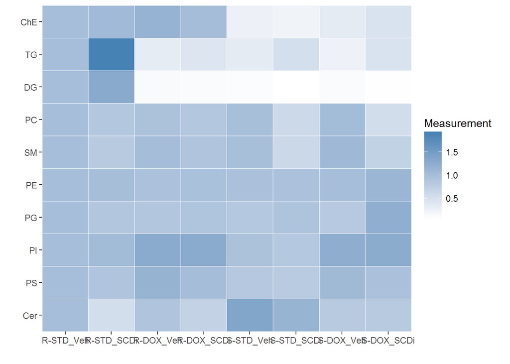

```r
string<- c("R-STD_Veh", "R-STD_SCDi", "R-DOX_Veh", "R-DOX_SCDi",
           "S-STD_Veh", "S-STD_SCDi", "S-DOX_Veh", "S-DOX_SCDi")


mk.names<- function(string, df){
  # uses grep string to identify all column names in a dataframe that contain this term
  # takes dataframe and vector of character strings corresponding to groupings
  # output is a list. name of list elements corresponds to group, contents to samples in that group

    out1<- vector("list", length = length(string))
  for (i in 1:length(string)){
    x <-  names(df)[grep(string[i], names(df))]
    out1[[i]]<- x
    names(out1)[i]<- string[i]
  }
  out1

}

names1<- mk.names(string = string, satlist1[["TG"]])


abund<- function(df, exclude=c()){
  ## df: dataframe containg raw abundance for each lipid (each row = 1 lipid, each column= one sample).
  ## exclude: columns to exclude from output. Auto excludes "Label" column, which contains lipid names
  ## function operation
    ### take column means and copy into a dataframe
      #### structure of this dataframe:
      #### columns are replicate names
      #### each row corresponds to different lipid type
    ###output this dataframe
  exclude2<- c("Label", exclude)
  excluded<- select(df, one_of(exclude2))
  included<- names(df)[!(names(df)%in% exclude2)] #vector of included columns
  df2<- select(df, one_of(included))
  colSums(df2)
   # df2
}


abundance<- t(as.data.frame(sapply(liplist2, abund)))  #use vapply instead?
#abundance2<- scale(abundance, center = FALSE, scale = colMeans((abundance)))
#abundance2<- sweep(abundance, 2, colSums(abundance), "/") ##maybe need to do this after adding group together?

group.mean<- function(vec, df){
  ## takes dataframe, subsets only columns included in "vec"
  ## calculates rowMeans for reduced dataframe
  df2<- df[, colnames(df) %in% vec]
  mns<- rowMeans(df2, na.rm = TRUE)
  mns
}

#
# abundance3<- vapply(names1, group.mean, abundance2, FUN.VALUE = numeric(nrow(abundance2)))
# abundance4<- sweep(abundance3, 1, abundance3[,1], "/")
# abundance5<- as.data.frame(abundance4) #as.data.frame(abundance4[, 2:ncol(abundance4)])
# abundance5$Lipid<- c(rownames(abundance5))
# long_abundance<- gather(abundance5, key = Group, value= Measurement, 1:8)



ht.map<- function(names, df, ctrl_group){
  ## df containing each sample in a differnet row, with total abundance of each lipid type in each column
  ## names: list of vectors corresponding to sample groups. name of vector is group name, elements of vector are replicates of that group.
    ### each dataframe, for loop over elements of "names"
    ### identify columns corresponding to elements of names vector

  df2<- vapply(names, group.mean, df, FUN.VALUE = numeric(nrow(df)))
  if (!ctrl_group %in% colnames(df2)){
    stop("Incorrect group name for control group")
  }
  ctrl<- df2[,colnames(df2)==ctrl_group]
  df3<- sweep(df2, 1, ctrl, "/")
  df4<- as.data.frame(df3) #as.data.frame(abundance4[, 2:ncol(abundance4)])
  df4$Lipid<- c(rownames(df4))
  long_abundance<- gather(df4, key = Group, value= Measurement, 1:(ncol(df4)-1))
  long_abundance
}


long_abundance<- ht.map(names = names1, df= abundance, ctrl_group = "R-STD_Veh") # does not normalize each sample so sum = 1
# long_abundance2<- ht.map(names = names1, df= abundance2, ctrl_group = "R-STD_Veh") # each sample normalized so sum = 1
# long_abundance3<- ht.map(names = names1, df= abundance2, ctrl_group = "S-STD_Veh") # each sample normalized so sum = 1


## changing order of lipids
lips<-unique(long_abundance$Lipid)
lips2<- c(lips[c(1,  8,  7,  6,  5,  9,  4,  3, 10,  2)])
long_abundance$Lipid<- factor(long_abundance$Lipid, levels = lips2)

# o<- ggplot(long_abundance3, aes(Group, Lipid))  + geom_tile(aes(fill = Measurement), colour = "white")
# o<- o + scale_fill_gradient(low = "white", high = "steelblue")
# o


p<- ggplot(long_abundance, aes(Group, Lipid))  + geom_tile(aes(fill = Measurement), colour = "white")
p<- p + scale_fill_gradient(low = "white", high = "steelblue")
p<- p+ theme_grey() + labs(x = "", y = "") + scale_x_discrete(expand = c(0, 0))
p<- p+ scale_y_discrete(expand = c(0, 0))

p
```

```r
# need to introduce procedure to censor ouliers further upstream to be consistent with previous analyses!
# censoring two samples based on being extreme outliers for DG abundance (see below)
# would it be better to censor those samples only for DG measurements?
# need more formalized test for outliers

censor<- c("R-STD_SCDi_5", "R-STD_Veh_5")
censored<- setdiff(names(as.data.frame(abundance)), censor)
abundance_cens<- select(as.data.frame(abundance), one_of(censored))
long_abundance_cens<- ht.map(names = names1, df= abundance_cens, ctrl_group = "R-STD_Veh")
long_abundance_cens$Lipid<- factor(long_abundance_cens$Lipid, levels = lips2)
p_c<- ggplot(long_abundance_cens, aes(Group, Lipid))  + geom_tile(aes(fill = Measurement), colour = "white")
p_c<- p_c + scale_fill_gradient(low = "white", high = "steelblue")
p_c<- p_c+ theme_grey() + labs(x = "", y = "") + scale_x_discrete(expand = c(0, 0))
p_c<- p_c+ scale_y_discrete(expand = c(0, 0))





#################################################################################
##making figure here
#ggsave("./20160205/heat_cens.pdf", plot = p_c, width=10, height=7, useDingbats=FALSE)
```

Problem here is that entire sample was censored even though it only seems to be an outlier when it comes to DG measurements. Now attempting to censor only DG values. Attempting to replace relevant values with NAs in liplist2 list of dataframes

```r
df<-as.data.frame(abundance)
to_censor<- c("R-STD_SCDi_5", "R-STD_Veh_5")
df[,to_censor]<- NA
to_censor[1]==names(df)
```

```
##  [1] FALSE FALSE FALSE FALSE FALSE FALSE FALSE FALSE FALSE FALSE FALSE
## [12] FALSE FALSE FALSE FALSE FALSE FALSE FALSE FALSE FALSE FALSE FALSE
## [23] FALSE FALSE FALSE FALSE FALSE FALSE FALSE FALSE FALSE FALSE FALSE
## [34]  TRUE FALSE FALSE FALSE FALSE FALSE
```

```r
all(to_censor %in% names(df))
```

```
## [1] TRUE
```

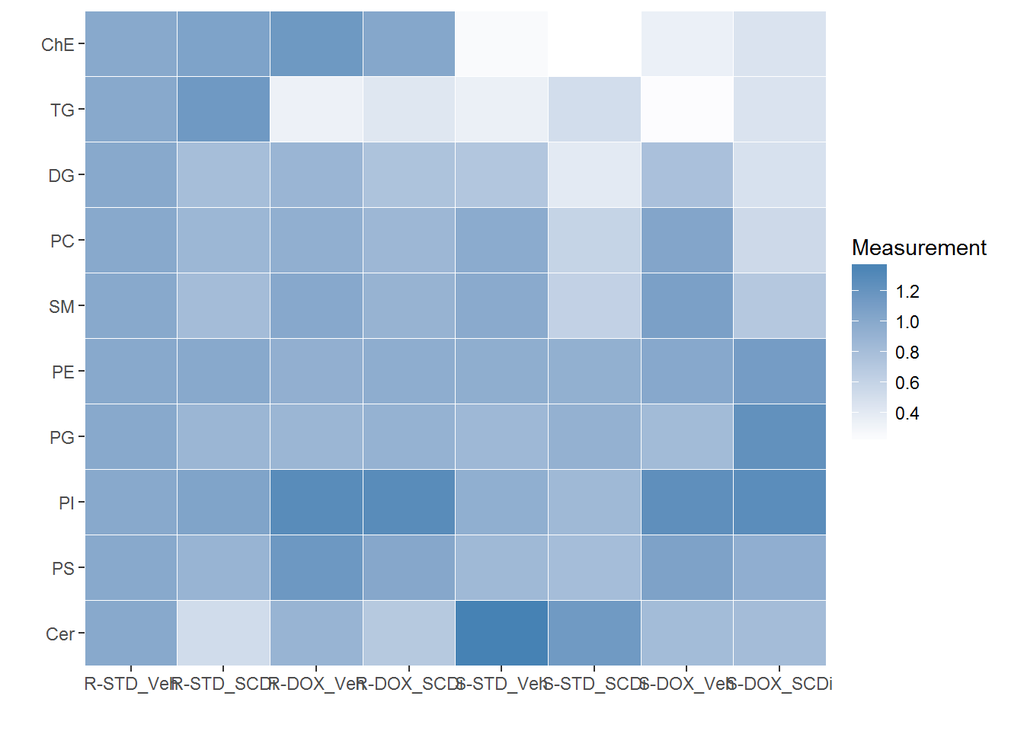

```r
samp.cens<- function(df, to_censor){
  ## take df with samples in columns according to sample name and each row = different lipid
  ## take vector of sample names that need to be removed
  ## output dataframe with values in those columns replaced by NA
  if (!(all(to_censor %in% names(df)))){
    stop("Incorrect sample names")
  }
  df[,to_censor]<- NA
  df
  #cens<- setdiff(names(df), to_censor)
  #   for (i in 1:length(to_censor)){
#
#   }
}

to_censor<- vector("list", length = length(liplist2))
names(to_censor)<- names(liplist2)
to_censor[["DG"]]<- c("R-STD_SCDi_5", "R-STD_Veh_5")
to_censor[["TG"]]<- c("R-STD_SCDi_5")  # also censoring this sample for TGs. Really changes outcome, far above others
                                       # perform statistical test for outlier

liplist3<- Map(samp.cens, liplist2, to_censor)
abundance_cens2<- t(as.data.frame(sapply(liplist3, abund)))

## now making heatmap with DG values censored only
long_abundance_cens2<- ht.map(names = names1, df= abundance_cens2, ctrl_group = "R-STD_Veh")



long_abundance_cens2$Lipid<- factor(long_abundance_cens2$Lipid, levels = lips2)
p_c2<- ggplot(long_abundance_cens2, aes(Group, Lipid))  + geom_tile(aes(fill = Measurement), colour = "white")
p_c2<- p_c2 + scale_fill_gradient(low = "white", high = "steelblue")
p_c2<- p_c2+ theme_grey() + labs(x = "", y = "") + scale_x_discrete(expand = c(0, 0))
p_c2<- p_c2+ scale_y_discrete(expand = c(0, 0))
p_c2
```

Make figure comparing any named groups for any lipid type.

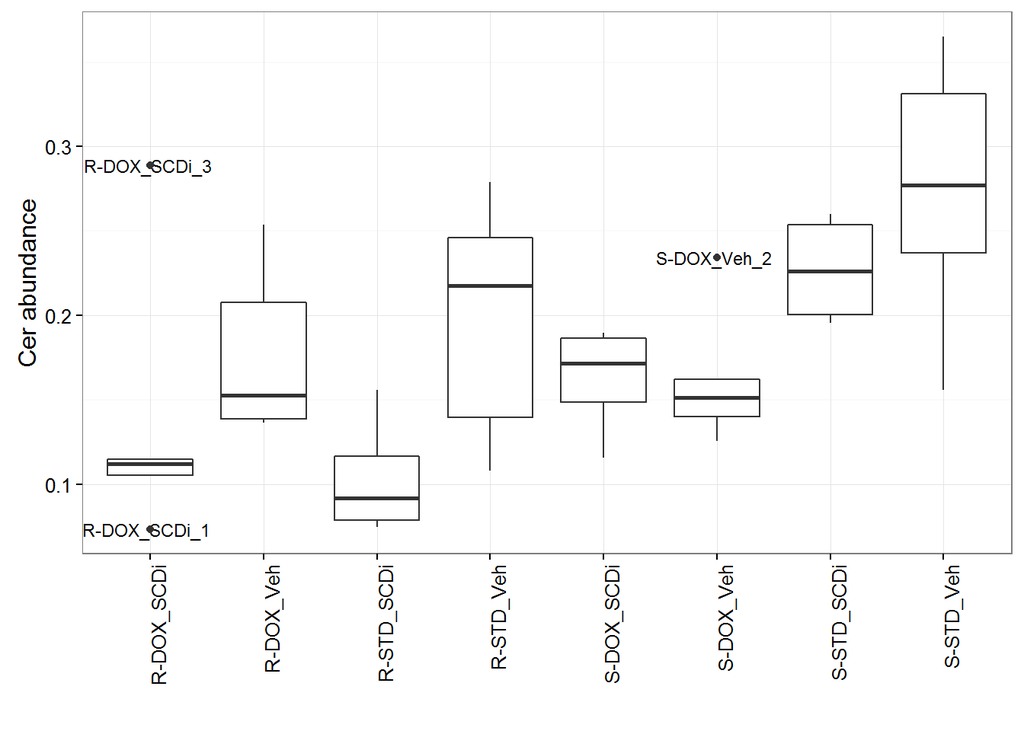

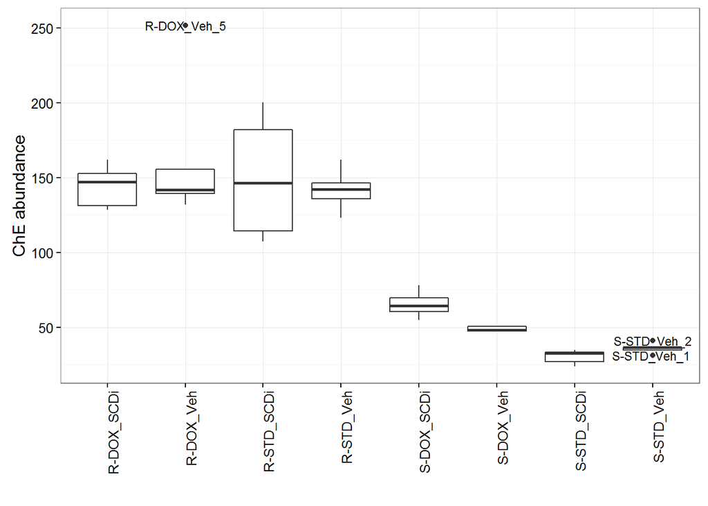

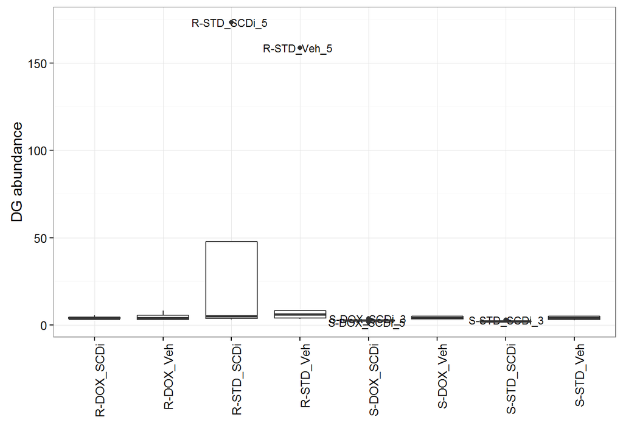

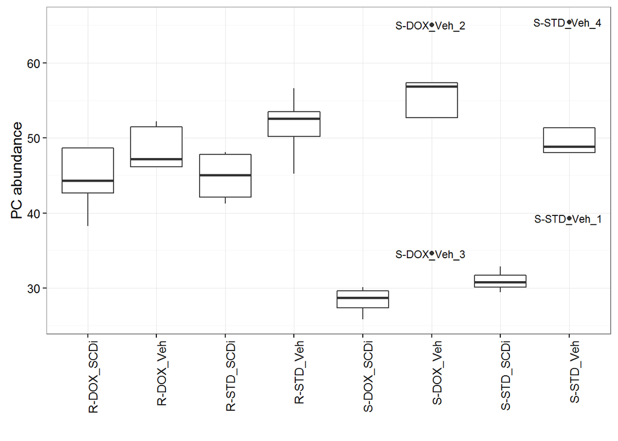

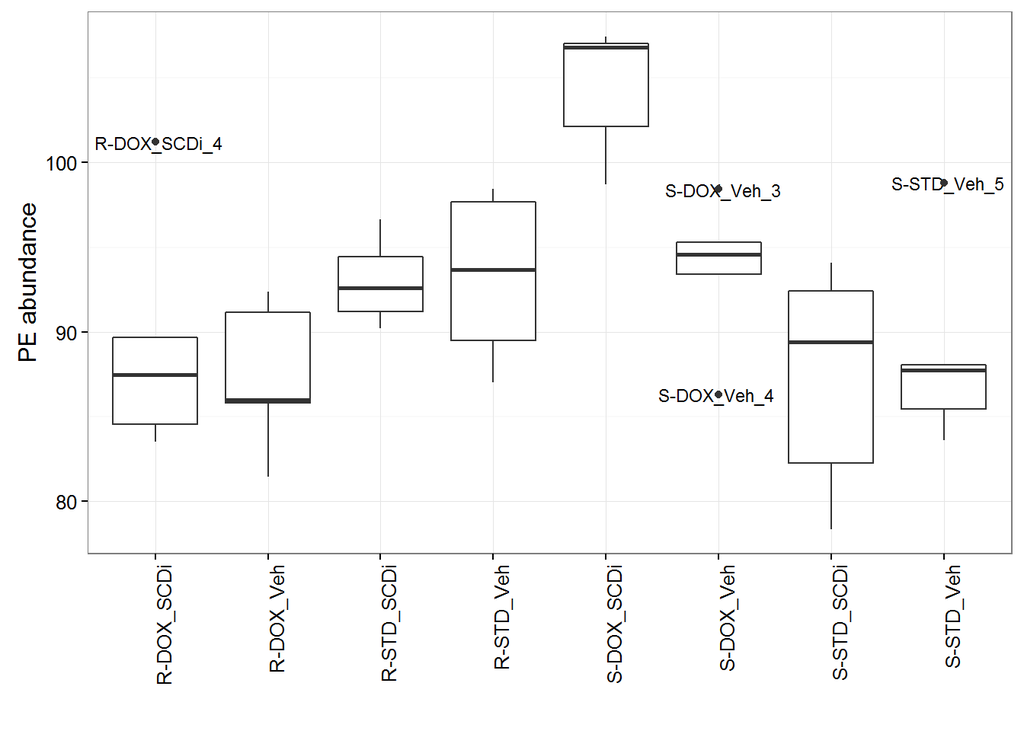

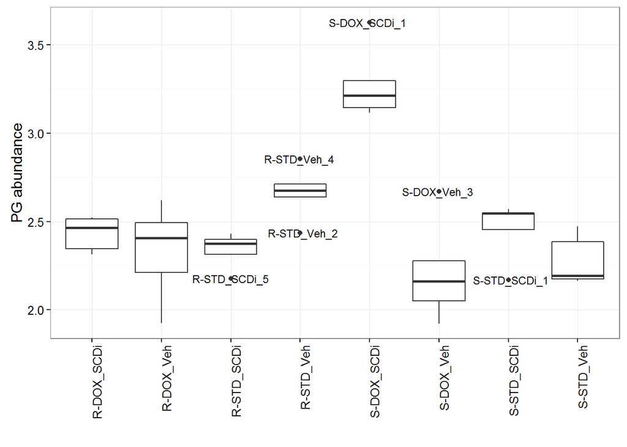

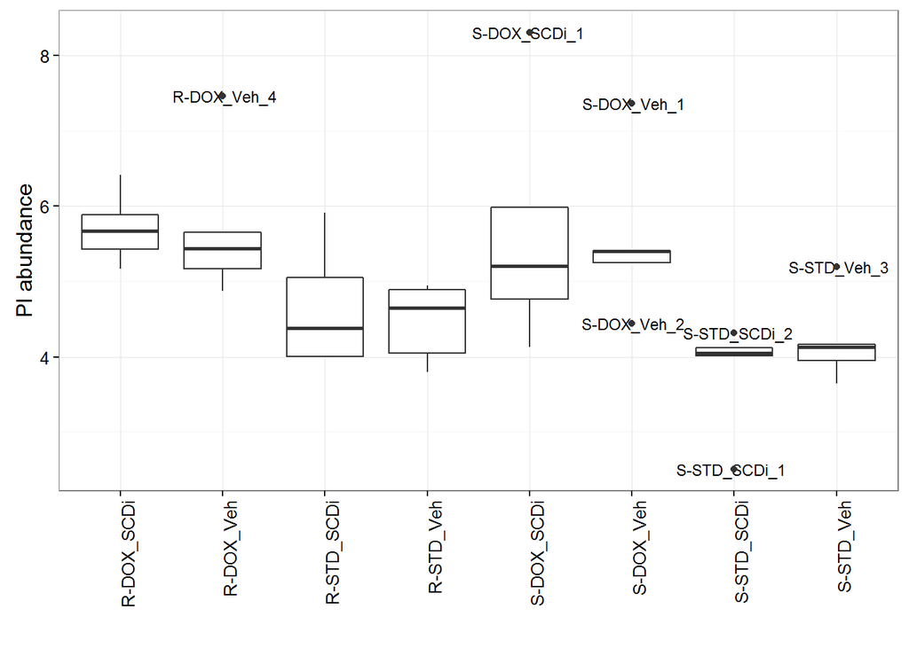

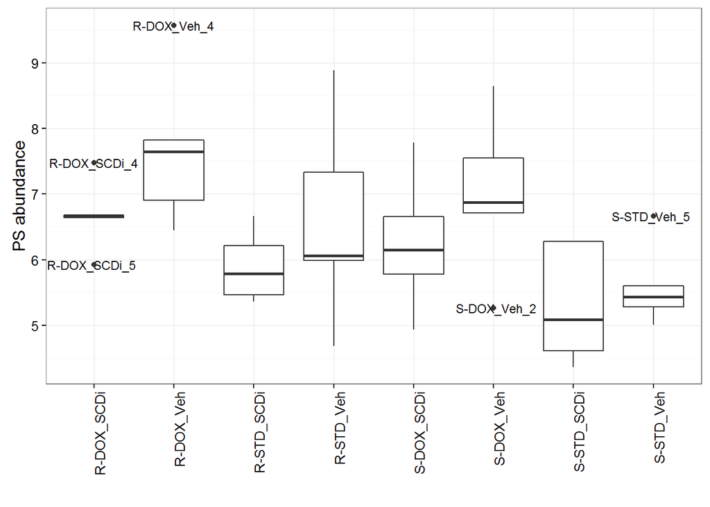

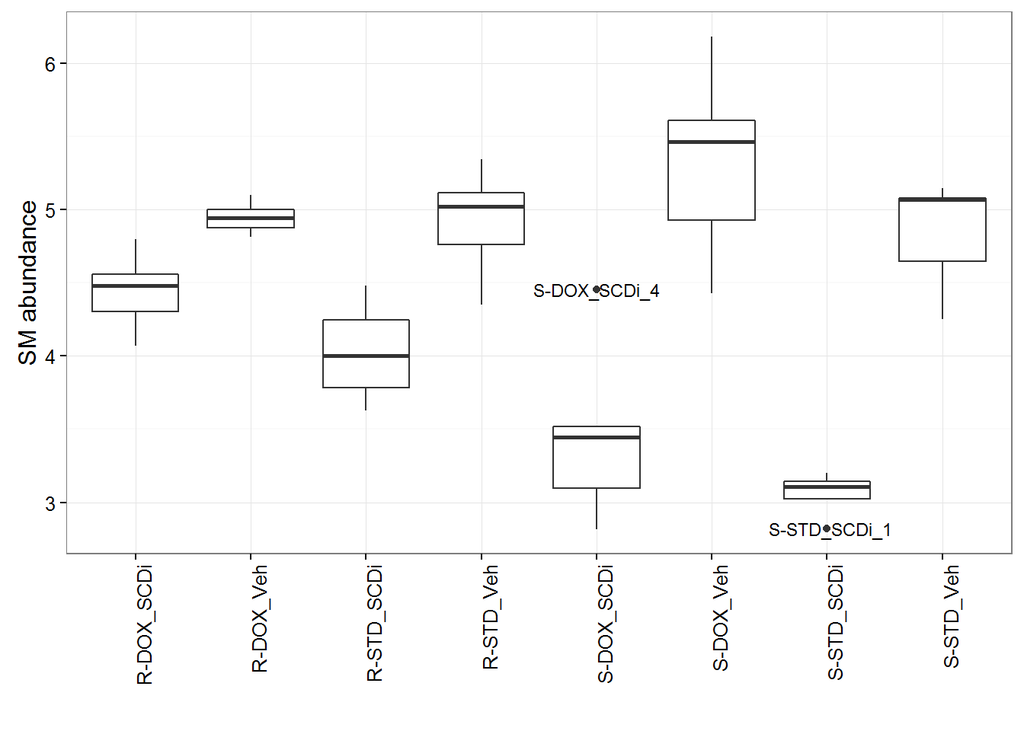

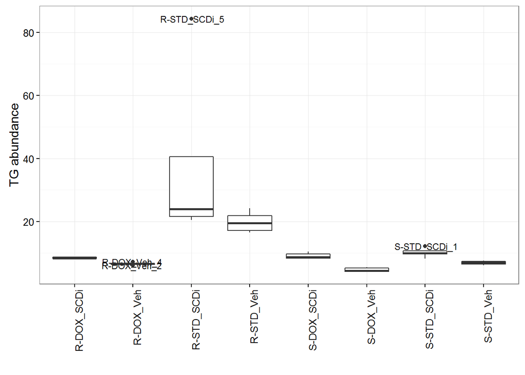

```r
sem<- function(vec){
  sm<- sd(vec)/sqrt(length(vec))
}

group.sem<- function(vec, df){
  ## takes dataframe, subsets only columns included in "vec"
  ## calculates rowMeans for reduced dataframe
  df2<- df[, colnames(df) %in% vec]
  sem<- apply(df, 1, sem)
  sem
}

# vec<- names1[["R-STD_Veh"]]
# df<- abundance



lip.abund<- function(lip,df, groups, nms= names1){
  ## takes dataframe, subsets groups = vector of character strings corresponding to groups of interest within names.
  ### dataframe: rows= total abundance by lipid type, columns = samples
  ## takes names, a list of character strings. Element names = group names, element contents = samples within that group
  ## takes lip, a character string corresponding to one of the following lipids present as row in df
  ## extracts abundance of lipid selected through "lip" for groups selected in "groups"
  ## outputs ggplot object

  samples<- c()
  names2<- nms[groups]
  for(i in 1:length(groups)){
    samples<- c(samples, names2[[i]])
  }
  df2<- select(df, one_of(samples))%>% add_rownames(var = "lipid")%>%filter(lipid==lip)%>% gather(Sample, Measurement, 2:(length(samples)+1))
  df2$Group<- NA
  for (i in 1:length(groups)){
#     grp<-groups[i]
#     gr_samples<-
    df2$Group[df2$Sample %in% names2[[i]]]<- names(names2)[i]
    }

  df3<- df2%>%group_by(Group)%>% mutate(lQntl = quantile(Measurement, probs = 0.25, na.rm = TRUE),
                uQntl = quantile(Measurement, probs = 0.75, na.rm = TRUE), lBound = lQntl - 1.5 * (uQntl - lQntl),
                uBound = uQntl + 1.5 * (uQntl - lQntl))
  df3$OL<-df3$Sample
  df3$OL[!(df3$Measurement<=df3$lBound |df3$Measurement>=df3$uBound)]<- NA


  ggplot(df3, aes(x=Group, y=Measurement))  +geom_boxplot() +geom_text(aes(label = OL), size = 3,
            position = position_jitter(width = 0.1))
}

# df<- as.data.frame(abundance)
# lip<- "DG"
# groups<- c("R-STD_Veh", "R-STD_SCDi")
# nms<- names1
#


lipids_list<-as.list(lipids)
names(lipids_list)<- lipids

ser_ab_effect<- lapply(lipids_list, lip.abund, df=as.data.frame(abundance), groups = c("R-STD_Veh", "S-STD_Veh"), nms = names1)
# ser_ab_effect[["DG"]] + theme_bw()+ labs(x="", y="abundance")


ab_effects <- lapply(lipids_list, lip.abund, df=as.data.frame(abundance), groups = names(names1), nms = names1)

f<- ser_ab_effect[["TG"]]+ geom_boxplot()+ labs(x="", y="Triglyceride abundance") + theme_bw()
f<- f+ coord_cartesian(ylim=c(0, 25))+theme(panel.border= element_blank(), axis.line = element_line(colour = "black"))
f<- f  + scale_x_discrete(labels=c("5% serum", "0.5% serum"))

#
# #################################################################################
# ##making figure here
# #ggsave("./20160205/TGabund2.pdf", plot = f, width=4, height=7, useDingbats=FALSE)
#
#
for (i in 1:length(ser_ab_effect)){
  fig1<- ab_effects[[i]]+ geom_boxplot()+ labs(x="", y=paste(names(ser_ab_effect)[i], "abundance")) + theme_bw()
  fig1<- fig1 + theme(axis.text.x = element_text(angle = 90, hjust = 1))
  print(fig1)
  }
```